# Sample_indexing

Fabian Roger

2023-10-02

Loading libraries

```r
library(dplyr)
library(tidyr)
library(readxl)
library(jsonlite)
library(Biostrings)
library(here)
library(clipr)
```

# demultiplexing by index

I use the [pheniqs](https://biosails.github.io/pheniqs/) software for demultiplexing.

> Galanti L, Shasha D, Gunsalus KC. 2021 Pheniqs 2.0: accurate, high-performance Bayesian decoding and confidence estimation for combinatorial barcode indexing. BMC Bioinformatics 22, 359. (doi:10.1186/s12859-021-04267-5)

It uses Phred adjusted maximum likelihood decoding > A maximum likelihood decoder that directly estimates the decoding error probability from the base calling error probabilities provided by the sequencing platform. Abbreviated PAMLD.

We need to provide it with a configuration file that links the samples to the dual unique indices.

## indices

We used the Nextera Indecies from Shinis Group for barcoding. However, different markes were barcoded with different sample arrangements, so that we first demultiplex by barcode and then assign samples.

```r
shini_barcodes <- read_xlsx(here("Documents", "Shini_barcodes_4_plates.xlsx"))

shini_barcodes <-
  shini_barcodes %>%
  select(1,2) %>%
  mutate(P5_P7 = gsub(".+_.+_(.+)", "\\1", `DNA Oligo Name`),
         Plate = rep(rep(1:4, each = 96),2)) %>%
  mutate(Barcode = gsub("CAAGCAGAAGACGGCATACGAGAT(.+)GTCTCGTGGGCTCGG", "\\1", `DNA Sequence (5' -> 3')`)) %>%
  mutate(Barcode = gsub("AATGATACGGCGACCACCGAGATCTACAC(.+)TCGTCGGCAGCGTC", "\\1", Barcode)) %>%
  mutate(name = gsub("(.+_.+)_.+", "\\1", `DNA Oligo Name`)) %>%
  select(-`DNA Sequence (5' -> 3')`, -`DNA Oligo Name`) %>%
  pivot_wider(names_from = P5_P7, values_from = Barcode) %>%
 # select(Plate, name, i5, i7) %>%
  mutate(i7_rc = as.character(reverseComplement(DNAStringSet(i7)))) %>%
  mutate(i5_rc = as.character(reverseComplement(DNAStringSet(i5))))# %>%
#  filter(Plate %in% c(1,2))
```

## configuration file

phenix takes a json formatted configuration file. An example is given [here](https://github.com/biosails/pheniqs/blob/master/example/illumina_vignette/H7LT2DSXX_l01_sample_static.json) which we take as basis for modification

```r
phenix_config <- read_json(here("Data", "iSeq", "20230913_FS10000965_17_BSB09423-1124", "phenix_config_file.json"))
```

## base configurations

Here we give the + input directory (where the files are) + output directory (where the files should be written to) + the 4 filenames (reads (R) and indices (I) for forward and reverse) + and the filename of the sample report

note that $output will be ignored if we write the reads to demultiplexed fastq files

```r
phenix_config$PM <- "unkown"

phenix_config$`base input url` <- here("Data", "iSeq", "20230913_FS10000965_17_BSB09423-1124")

phenix_config$`base output url` <- here("Data", "iSeq", "20230913_FS10000965_17_BSB09423-1124", "demultiplexed")

phenix_config$`flowcell id` <- "unkown"

#forward reads
phenix_config$input[[1]] <- "Undetermined_S0_L001_R1_001.fastq.gz"

#forward index
phenix_config$input[[2]] <- "Undetermined_S0_L001_I1_001.fastq.gz"

#reverse index
phenix_config$input[[3]] <- "Undetermined_S0_L001_I2_001.fastq.gz"

#reverse reads
phenix_config$input[[4]] <- "Undetermined_S0_L001_R2_001.fastq.gz"

#output
phenix_config$output[[1]] <- "Undetermined_S0_L001.bam"

#report
phenix_config$`report url` <- "sample_report.json"
```

#barcodes

Here we format the core of the configuration file, associating each sample with the unique barcode configuration

shini_barcodes is a dataframe containing the sample indicies, the P5 barcode, the P7 barcode and the reverseComplement of the barcode (in my case)

```r
my_config <-
phenix_config$sample$codec[1:nrow(shini_barcodes)]

names(my_config) <- paste("@", shini_barcodes$name, sep ="")

for(i in names(my_config)){

  sample <- gsub("@", "", i)
  my_config[[i]]$LB <- sample
  my_config[[i]]$barcode[[1]] <- shini_barcodes[shini_barcodes$name == sample,]$i7_rc
  my_config[[i]]$barcode[[2]] <- shini_barcodes[shini_barcodes$name == sample,]$i5_rc

  my_config[[i]]$output[[1]] <- paste(sample, "_R1.fastq.gz", sep ="")
  my_config[[i]]$output[[2]] <- paste(sample, "_R2.fastq.gz", sep ="")

}

phenix_config$sample$codec <- my_config

phenix_config$sample$undetermined$output[[1]] <- "unclear_barcode_R1.fastq.gz"
phenix_config$sample$undetermined$output[[2]] <- "unclear_barcode_R2.fastq.gz"

#barcode length 10 bp
phenix_config$sample$transform$token[[1]] <- "1::10"
phenix_config$sample$transform$token[[2]] <- "2::10"
```

## Save configuration file

```r
path_to_file <- here("Data", "iSeq", "20230913_FS10000965_17_BSB09423-1124", "phenix_config_iSeq.json")

write_json(phenix_config, path_to_file, pretty = T, auto_unbox = TRUE)
```

##create output folder

```r
dir.create(phenix_config$`base output url`)
```

## run pheniqs

```r
system(paste("/Users/fabian/pheniqs_head_static/bin/static-HEAD/install/bin/pheniqs mux --config ",path_to_file, sep = ""))
```

```
[W::bgzf_read_block] EOF marker is absent. The input is probably truncated
[W::bgzf_read_block] EOF marker is absent. The input is probably truncated
[W::bgzf_read_block] EOF marker is absent. The input is probably truncated
[W::bgzf_read_block] EOF marker is absent. The input is probably truncated
```

## check report

```r
report <- read_json(here("Data", "iSeq", "20230913_FS10000965_17_BSB09423-1124","demultiplexed", "sample_report.json"))
```

total number of reads

```r
report$outgoing$count
```

```
[1] 4373275
```

fraction of reads with valid indices

```r
report$outgoing$`pf fraction`
```

```
[1] 0.7714754
```

```r
report$sample$classified %>%
  lapply(., as.data.frame) %>%
  bind_rows() %>%
  select(LB, BC, count) %>%
  mutate(prct = signif(count/sum(count)*100, 2)) %>%
  arrange(desc(count))
```

| LB | BC | count | prct |
| --- | --- | --- | --- |
| NGS_UDP0056 | AACGCACGAG-TATCCGAGGC | 39840 | 1.2e+00 |
| NGS_UDP0068 | CACGGAACAA-GTGCTAGGTT | 39611 | 1.1e+00 |
| NGS_UDP0055 | CTGAGGAATA-AGTGGTTAAG | 39252 | 1.1e+00 |
| NGS_UDP0076 | CTGACTCTAC-TGACGGCCGT | 36314 | 1.0e+00 |
| NGS_UDP0081 | TGTCGCTGGT-AGTCAGACGA | 35403 | 1.0e+00 |
| NGS_UDP0057 | TCTATCCTAA-CCAGTCGACG | 34718 | 1.0e+00 |
| NGS_UDP0038 | GTGCAGACAG-ACGGATGGTA | 34440 | 1.0e+00 |
| NGS_UDP0083 | TATGCCTTAC-TAATGTGTCT | 34377 | 9.9e-01 |
| NGS_UDP0074 | TTCATAAGGT-CCTTCTAACA | 33833 | 9.8e-01 |
| NGS_UDP0046 | AGATCCATTA-TGGTAGAGAT | 33626 | 9.7e-01 |

[output cut: 182 more lines]

find barcodes

```r
I1 <- ShortRead::readFastq(here("Data", "iSeq", "20230913_FS10000965_17_BSB09423-1124", "Undetermined_S0_L001_I1_001.fastq.gz")) %>% ShortRead::sread()

I2 <- ShortRead::readFastq(here("Data", "iSeq", "20230913_FS10000965_17_BSB09423-1124", "Undetermined_S0_L001_I2_001.fastq.gz")) %>% ShortRead::sread()

BC <- tibble(I1 = as.character(I1),
             I2 = as.character(I2))
BC <-
BC %>%
  group_by(I1,I2) %>%
  summarise(n = n()) %>%
  arrange(desc(n)) %>%
  ungroup() %>%
  mutate(n_frac = round(n/sum(n) * 100,2))

BC %>%
  left_join(shini_barcodes, by = c("I1" = "i5_rc", "I2" = "i7_rc"))
```

I1 –> i7_rc

```r
sum(shini_barcodes$i7_rc %in% BC$I1)
```

```
[1] 184
```

I2 –> i5_rc

```r
sum(shini_barcodes$i5_rc %in% BC$I2)
```

```
[1] 183
```

# demultiplexing by primer

We pooled four different primer pairs

1. COI Primer for Insects (30%)
2. ITS Primer for Fungi (30%)
3. 16S Primer for Bacteria (30%)
4. 16S Primer for Vertebrates (10%)

I will use cutadapt to sort the reads by primer into separate files

I use [cutadapt](https://cutadapt.readthedocs.io/en/stable/guide.html) to sort the reads by primer into different files.

setting up variables:

```r
dm_files <- list.files(here("Data", "iSeq", "20230913_FS10000965_17_BSB09423-1124","demultiplexed"),
                        full.names = F)

dm_files <- dm_files[!grepl("unclear_barcode", dm_files)]

forward_raw <- dm_files[grepl("_R1.fastq.gz", dm_files)]
reverse_raw <- dm_files[grepl("_R2.fastq.gz", dm_files)]

#path to sequences
path_demulti <- here("Data", "iSeq", "20230913_FS10000965_17_BSB09423-1124","demultiplexed")

#minimum length for sequences after trimming (shorter sequences are discarded)
minlength <- 100

#number of cores to use
Cores <- 8
```

> 5’ adapters preceed the sequence of interest

### Insects

COI-ArtF12_P5 : GCHCCHGAYATRGCHTTYCCNC COI-ArtR22xls_P7: GRTCAAARAADGAWGTATTWARATTWCG

```r
Primer <- list()
Primer$Frwd <- "GCHCCHGAYATRGCHTTYCCNC"
Primer$Rev <- "GRTCAAARAADGAWGTATTWARATTWCG"

Primer$Frwd_rc <- as.character(reverseComplement(DNAStringSet(Primer$Frwd)))
Primer$Rev_rc <- as.character(reverseComplement(DNAStringSet(Primer$Rev)))
```

[output not shown]

### Vertebrates

For vertebrates I used primers targeting the mitochondrial vertebrate 16S gene The forward Primer has two versions, one targeting birds specifically

mam1 : GGTTGGGGTGACCTCGGA mam1_b : GGTTGGGGCGACCTTGGA Y Y ve16S : AATCGTTGAACAAACGAAC

```r
Primer <- list()
Primer$Frwd <- "GGTTGGGGYGACCTYGGA"
Primer$Rev <- "AATCGTTGAACAAACGAAC"

Primer$Frwd_rc <- as.character(reverseComplement(DNAStringSet(Primer$Frwd)))
Primer$Rev_rc <- as.character(reverseComplement(DNAStringSet(Primer$Rev)))
```

```r
#create directories for primer pair
Primer_path <- here("Data", "iSeq", "20230913_FS10000965_17_BSB09423-1124", "Vertebrates")
dir.create(Primer_path)
```

```r
cutadapt_out <- vector(mode = "list", length = length(forward_raw))
names(cutadapt_out) <- gsub("(.+?)_R\\d.+", "\\1", forward_raw)

for (i in seq_along(forward_raw)) {

  message(paste("processing file", i, "out of", length(forward_raw), sep=" "))

# will sort in separate file below
temp <-
system(
paste('cutadapt -a ', #replace by your path to cutadapt
      '"', Primer$Frwd,';required;min_overlap=12','"','...', Primer$Rev_rc,
      ' -A ', '"',Primer$Rev,';required;min_overlap=12','"', '...', Primer$Rev_rc,
      ' --discard-untrimmed',
      ' --minimum-length=', minlength, #minimum length for sequences after trimming
      ' --cores=', Cores, # Number of cores to use
      ' -o ', paste(Primer_path, '/', forward_raw[i], sep = ''),
      ' -p ', paste(Primer_path, '/', reverse_raw[i], sep = ''),
      paste(' ',path_demulti , '/', forward_raw[i], sep = ''),
      paste(' ', path_demulti, '/', reverse_raw[i], sep = ''),
      ' --report=minimal',
      sep = ''
      ), intern = TRUE
)

df <- read.table(text = temp)[2,]
colnames(df) <- read.table(text = temp)[1,]
cutadapt_out[[i]] <- df
}
```

```
processing file 1 out of 192
processing file 2 out of 192
processing file 3 out of 192
processing file 4 out of 192
processing file 5 out of 192
processing file 6 out of 192
processing file 7 out of 192
processing file 8 out of 192
processing file 9 out of 192
processing file 10 out of 192
processing file 11 out of 192
processing file 12 out of 192
processing file 13 out of 192
processing file 14 out of 192
processing file 15 out of 192
processing file 16 out of 192
processing file 17 out of 192
processing file 18 out of 192
processing file 19 out of 192
processing file 20 out of 192
processing file 21 out of 192
processing file 22 out of 192
processing file 23 out of 192
processing file 24 out of 192
processing file 25 out of 192
processing file 26 out of 192
processing file 27 out of 192
processing file 28 out of 192
processing file 29 out of 192
processing file 30 out of 192
processing file 31 out of 192
processing file 32 out of 192
processing file 33 out of 192
processing file 34 out of 192
processing file 35 out of 192
processing file 36 out of 192
processing file 37 out of 192
processing file 38 out of 192
processing file 39 out of 192
processing file 40 out of 192
```

[output cut: 137 more lines]

```
processing file 178 out of 192
processing file 179 out of 192
processing file 180 out of 192
processing file 181 out of 192
processing file 182 out of 192
processing file 183 out of 192
processing file 184 out of 192
processing file 185 out of 192
processing file 186 out of 192
processing file 187 out of 192
processing file 188 out of 192
processing file 189 out of 192
processing file 190 out of 192
processing file 191 out of 192
processing file 192 out of 192
```

```r
cutadapt_out_df <- bind_rows(cutadapt_out, .id = "Index")

cutadapt_out_df$Marker <- "Vertebrates"

cutadapt_out_df %>%
  write_tsv(here("Data", "iSeq", "cutadapt_stats_vertebrates.txt"))

cutadapt_out_df
```

| Index | status | in_reads | in_bp | too_short | too_long | too_many_n | out_reads | w/adapters | qualtrim_bp | out_bp | w/adapters2 | qualtrim2_bp | out2_bp | Marker |
| --- | --- | --- | --- | --- | --- | --- | --- | --- | --- | --- | --- | --- | --- | --- |
| NGS_UDP0001 | OK | 15385 | 4646270 | 70 | 0 | 0 | 119 | 189 | 0 | 15828 | 193 | 0 | 15709 | Vertebrates |
| NGS_UDP0002 | OK | 21664 | 6542528 | 142 | 0 | 0 | 285 | 431 | 0 | 37758 | 428 | 0 | 37621 | Vertebrates |
| NGS_UDP0003 | OK | 14395 | 4347290 | 105 | 0 | 0 | 148 | 253 | 0 | 19685 | 254 | 0 | 19535 | Vertebrates |
| NGS_UDP0004 | OK | 20767 | 6271634 | 83 | 0 | 0 | 217 | 305 | 0 | 28862 | 302 | 0 | 28644 | Vertebrates |
| NGS_UDP0005 | OK | 24858 | 7507116 | 95 | 0 | 0 | 519 | 620 | 0 | 69024 | 623 | 0 | 68508 | Vertebrates |
| NGS_UDP0006 | OK | 20571 | 6212442 | 83 | 0 | 0 | 560 | 649 | 0 | 74485 | 655 | 0 | 73920 | Vertebrates |
| NGS_UDP0007 | OK | 24316 | 7343432 | 82 | 0 | 0 | 223 | 309 | 0 | 29668 | 308 | 0 | 29436 | Vertebrates |
| NGS_UDP0008 | OK | 9982 | 3014564 | 150 | 0 | 0 | 348 | 501 | 0 | 46290 | 507 | 0 | 45932 | Vertebrates |
| NGS_UDP0009 | OK | 23964 | 7237128 | 116 | 0 | 0 | 481 | 602 | 0 | 63965 | 600 | 0 | 63495 | Vertebrates |
| NGS_UDP0010 | OK | 24908 | 7522216 | 117 | 0 | 0 | 291 | 411 | 0 | 38702 | 411 | 0 | 38409 | Vertebrates |

[output cut: 182 more lines]

### Bacteria

515F : GTGYCAGCMGCCGCGGTAA 806R : GGACTACNVGGGTWTCTAAT

```r
Primer <- list()
Primer$Frwd <- "GTGYCAGCMGCCGCGGTAA"
Primer$Rev <- "GGACTACNVGGGTWTCTAAT"

Primer$Frwd_rc <- as.character(reverseComplement(DNAStringSet(Primer$Frwd)))
Primer$Rev_rc <- as.character(reverseComplement(DNAStringSet(Primer$Rev)))
```

```r
#create directories for primer pair
Primer_path <- here("Data", "iSeq", "20230913_FS10000965_17_BSB09423-1124", "Bacteria")
dir.create(Primer_path)
```

```r
cutadapt_out <- vector(mode = "list", length = length(forward_raw))
names(cutadapt_out) <- gsub("(.+?)_R\\d.+", "\\1", forward_raw)

for (i in seq_along(forward_raw)) {

  message(paste("processing file", i, "out of", length(forward_raw), sep=" "))

# will sort in separate file below
temp <-
system(
paste('cutadapt -a ', #replace by your path to cutadapt
      '"', Primer$Frwd,';required;min_overlap=12','"','...', Primer$Rev_rc,
      ' -A ', '"',Primer$Rev,';required;min_overlap=12','"', '...', Primer$Rev_rc,
      ' --discard-untrimmed',
      ' --minimum-length=', minlength, #minimum length for sequences after trimming
      ' --cores=', Cores, # Number of cores to use
      ' -o ', paste(Primer_path, '/', forward_raw[i], sep = ''),
      ' -p ', paste(Primer_path, '/', reverse_raw[i], sep = ''),
      paste(' ',path_demulti , '/', forward_raw[i], sep = ''),
      paste(' ', path_demulti, '/', reverse_raw[i], sep = ''),
      ' --report=minimal',
      sep = ''
      ), intern = TRUE
)

df <- read.table(text = temp)[2,]
colnames(df) <- read.table(text = temp)[1,]
cutadapt_out[[i]] <- df
}
```

```
processing file 1 out of 192
processing file 2 out of 192
processing file 3 out of 192
processing file 4 out of 192
processing file 5 out of 192
processing file 6 out of 192
processing file 7 out of 192
processing file 8 out of 192
processing file 9 out of 192
processing file 10 out of 192
processing file 11 out of 192
processing file 12 out of 192
processing file 13 out of 192
processing file 14 out of 192
processing file 15 out of 192
processing file 16 out of 192
processing file 17 out of 192
processing file 18 out of 192
processing file 19 out of 192
processing file 20 out of 192
processing file 21 out of 192
processing file 22 out of 192
processing file 23 out of 192
processing file 24 out of 192
processing file 25 out of 192
processing file 26 out of 192
processing file 27 out of 192
processing file 28 out of 192
processing file 29 out of 192
processing file 30 out of 192
processing file 31 out of 192
processing file 32 out of 192
processing file 33 out of 192
processing file 34 out of 192
processing file 35 out of 192
processing file 36 out of 192
processing file 37 out of 192
processing file 38 out of 192
processing file 39 out of 192
processing file 40 out of 192
```

[output cut: 137 more lines]

```
processing file 178 out of 192
processing file 179 out of 192
processing file 180 out of 192
processing file 181 out of 192
processing file 182 out of 192
processing file 183 out of 192
processing file 184 out of 192
processing file 185 out of 192
processing file 186 out of 192
processing file 187 out of 192
processing file 188 out of 192
processing file 189 out of 192
processing file 190 out of 192
processing file 191 out of 192
processing file 192 out of 192
```

```r
cutadapt_out_df <- bind_rows(cutadapt_out, .id = "Index")

cutadapt_out_df$Marker <- "Bacteria"

cutadapt_out_df %>%
  write_tsv(here("Data", "iSeq", "cutadapt_stats_bacteria.txt"))

cutadapt_out_df
```

| Index | status | in_reads | in_bp | too_short | too_long | too_many_n | out_reads | w/adapters | qualtrim_bp | out_bp | w/adapters2 | qualtrim2_bp | out2_bp | Marker |
| --- | --- | --- | --- | --- | --- | --- | --- | --- | --- | --- | --- | --- | --- | --- |
| NGS_UDP0001 | OK | 15385 | 4646270 | 70 | 0 | 0 | 119 | 189 | 0 | 15828 | 193 | 0 | 15709 | Bacteria |
| NGS_UDP0002 | OK | 21664 | 6542528 | 142 | 0 | 0 | 285 | 431 | 0 | 37758 | 428 | 0 | 37621 | Bacteria |
| NGS_UDP0003 | OK | 14395 | 4347290 | 105 | 0 | 0 | 148 | 253 | 0 | 19685 | 254 | 0 | 19535 | Bacteria |
| NGS_UDP0004 | OK | 20767 | 6271634 | 83 | 0 | 0 | 217 | 305 | 0 | 28862 | 302 | 0 | 28644 | Bacteria |
| NGS_UDP0005 | OK | 24858 | 7507116 | 95 | 0 | 0 | 519 | 620 | 0 | 69024 | 623 | 0 | 68508 | Bacteria |
| NGS_UDP0006 | OK | 20571 | 6212442 | 83 | 0 | 0 | 560 | 649 | 0 | 74485 | 655 | 0 | 73920 | Bacteria |
| NGS_UDP0007 | OK | 24316 | 7343432 | 82 | 0 | 0 | 223 | 309 | 0 | 29668 | 308 | 0 | 29436 | Bacteria |
| NGS_UDP0008 | OK | 9982 | 3014564 | 150 | 0 | 0 | 348 | 501 | 0 | 46290 | 507 | 0 | 45932 | Bacteria |
| NGS_UDP0009 | OK | 23964 | 7237128 | 116 | 0 | 0 | 481 | 602 | 0 | 63965 | 600 | 0 | 63495 | Bacteria |
| NGS_UDP0010 | OK | 24908 | 7522216 | 117 | 0 | 0 | 291 | 411 | 0 | 38702 | 411 | 0 | 38409 | Bacteria |

[output cut: 182 more lines]

### Fungi

```r
ITS_primer <- read_xlsx(here("Data", "Fungal_primer_Schlegel.xlsx"))
```

we seqeuence wit a mix of primers, we specify the adapters in seperate files:

```r
ITS_fwrd <-
ITS_primer %>%
  filter(Primer_dir == "Fwrd") %>%
  pull(`primer sequence`) %>%
  unique() %>%
  DNAStringSet()

fwrd_search <-
paste(ITS_fwrd, ";required;min_overlap=12","...",reverseComplement(ITS_fwrd), sep = "")

paste(">primer", 1:length(fwrd_search), sep = "_") %>%
  rbind(., fwrd_search) %>%
  c() %>%
  write_lines(here("Data", "ITS_Primer_fwrd.fasta"))


ITS_rev <-
ITS_primer %>%
  filter(Primer_dir == "Rev") %>%
  pull(`primer sequence`) %>%
  unique() %>%
  DNAStringSet()

rev_search <-
paste(ITS_rev, ";required;min_overlap=12","...",reverseComplement(ITS_rev), sep = "")

paste(">primer", 1:length(rev_search), sep = "_") %>%
  rbind(., rev_search) %>%
  c() %>%
  write_lines(here("Data", "ITS_Primer_rev.fasta"))
```

```r
#create directories for primer pair
Primer_path <- here("Data", "iSeq", "20230913_FS10000965_17_BSB09423-1124", "Fungi")
dir.create(Primer_path)
```

```r
cutadapt_out <- vector(mode = "list", length = length(forward_raw))
names(cutadapt_out) <- gsub("(.+?)_R\\d.+", "\\1", forward_raw)

for (i in seq_along(forward_raw)) {

  message(paste("processing file", i, "out of", length(forward_raw), sep=" "))

# will sort in separate file below
temp <-
system(
paste('cutadapt -a ', #replace by your path to cutadapt
      '"',
      'file:',here("Data", "ITS_Primer_fwrd.fasta"),
      '"',
      ' -A ',
      '"',
      'file:', here("Data", "ITS_Primer_rev.fasta"),
      '"',
      ' --discard-untrimmed',
      ' --minimum-length=', minlength, #minimum length for sequences after trimming
      ' --cores=', Cores, # Number of cores to use
      ' -o ', paste(Primer_path, '/', forward_raw[i], sep = ''),
      ' -p ', paste(Primer_path, '/', reverse_raw[i], sep = ''),
      paste(' ',path_demulti , '/', forward_raw[i], sep = ''),
      paste(' ', path_demulti, '/', reverse_raw[i], sep = ''),
      ' --report=minimal',
      sep = ''
      ), intern = TRUE
)

df <- read.table(text = temp)[2,]
colnames(df) <- read.table(text = temp)[1,]
cutadapt_out[[i]] <- df
}
```

```
processing file 1 out of 192
processing file 2 out of 192
processing file 3 out of 192
processing file 4 out of 192
processing file 5 out of 192
processing file 6 out of 192
processing file 7 out of 192
processing file 8 out of 192
processing file 9 out of 192
processing file 10 out of 192
processing file 11 out of 192
processing file 12 out of 192
processing file 13 out of 192
processing file 14 out of 192
processing file 15 out of 192
processing file 16 out of 192
processing file 17 out of 192
processing file 18 out of 192
processing file 19 out of 192
processing file 20 out of 192
processing file 21 out of 192
processing file 22 out of 192
processing file 23 out of 192
processing file 24 out of 192
processing file 25 out of 192
processing file 26 out of 192
processing file 27 out of 192
processing file 28 out of 192
processing file 29 out of 192
processing file 30 out of 192
processing file 31 out of 192
processing file 32 out of 192
processing file 33 out of 192
processing file 34 out of 192
processing file 35 out of 192
processing file 36 out of 192
processing file 37 out of 192
processing file 38 out of 192
processing file 39 out of 192
processing file 40 out of 192
```

[output cut: 137 more lines]

```
processing file 178 out of 192
processing file 179 out of 192
processing file 180 out of 192
processing file 181 out of 192
processing file 182 out of 192
processing file 183 out of 192
processing file 184 out of 192
processing file 185 out of 192
processing file 186 out of 192
processing file 187 out of 192
processing file 188 out of 192
processing file 189 out of 192
processing file 190 out of 192
processing file 191 out of 192
processing file 192 out of 192
```

```r
cutadapt_out_df <- bind_rows(cutadapt_out, .id = "Index")

cutadapt_out_df$Marker <- "Fungi"

cutadapt_out_df %>%
  write_tsv(here("Data", "iSeq", "cutadapt_stats_fungi.txt"))

cutadapt_out_df
```

| Index | status | in_reads | in_bp | too_short | too_long | too_many_n | out_reads | w/adapters | qualtrim_bp | out_bp | w/adapters2 | qualtrim2_bp | out2_bp | Marker |
| --- | --- | --- | --- | --- | --- | --- | --- | --- | --- | --- | --- | --- | --- | --- |
| NGS_UDP0001 | OK | 15385 | 4646270 | 0 | 0 | 0 | 2794 | 2857 | 0 | 357996 | 2864 | 0 | 355378 | Fungi |
| NGS_UDP0002 | OK | 21664 | 6542528 | 0 | 0 | 0 | 3237 | 3313 | 0 | 413484 | 3347 | 0 | 411449 | Fungi |
| NGS_UDP0003 | OK | 14395 | 4347290 | 0 | 0 | 0 | 25 | 53 | 0 | 3222 | 56 | 0 | 3179 | Fungi |
| NGS_UDP0004 | OK | 20767 | 6271634 | 0 | 0 | 0 | 3401 | 3668 | 0 | 436554 | 4386 | 0 | 432100 | Fungi |
| NGS_UDP0005 | OK | 24858 | 7507116 | 0 | 0 | 0 | 4604 | 4727 | 0 | 591841 | 4773 | 0 | 585348 | Fungi |
| NGS_UDP0006 | OK | 20571 | 6212442 | 0 | 0 | 0 | 3855 | 4134 | 0 | 496543 | 4898 | 0 | 489878 | Fungi |
| NGS_UDP0007 | OK | 24316 | 7343432 | 0 | 0 | 0 | 2889 | 3011 | 0 | 371876 | 2975 | 0 | 367397 | Fungi |
| NGS_UDP0008 | OK | 9982 | 3014564 | 0 | 0 | 0 | 52 | 72 | 0 | 6717 | 93 | 0 | 6592 | Fungi |
| NGS_UDP0009 | OK | 23964 | 7237128 | 0 | 0 | 0 | 3329 | 3427 | 0 | 427047 | 3423 | 0 | 423349 | Fungi |
| NGS_UDP0010 | OK | 24908 | 7522216 | 0 | 0 | 0 | 3078 | 3168 | 0 | 396712 | 3180 | 0 | 391434 | Fungi |

[output cut: 182 more lines]

# count PhiX

```r
dir.create(here("Data", "iSeq", "bbduk_stats"))

lapply(seq_along(forward_raw), function(x)
{

  system(paste("/Applications/bbmap/bbduk.sh in1=",
               paste(path_demulti , '/', forward_raw[x], sep = ''),
               " in2=",
               paste(path_demulti , '/', reverse_raw[x], sep = ''),
               " stats=",
               paste(here("Data", "iSeq", "bbduk_stats"),
                     paste("bbduk", x, ".txt", sep = ""), sep = "/"),
               " maxns=0",
               " ref=/Applications/bbmap/resources/phix174_ill.ref.fa.gz k=20 hdist=2",
               " threads=6",
                sep = ""
               ), intern = TRUE)

})
```

```r
bbduk_files <- list.files(here("Data", "iSeq", "bbduk_stats"), full.names = TRUE)

phix = lapply(bbduk_files, function(x){
  temp <- read_lines(x)
  strsplit(temp[3], "\t")[[1]][2]
}) %>% unlist() %>% as.numeric

bbduk_stat <- tibble(Index = gsub("(.+?)_R\\d.+", "\\1", forward_raw),
                     phiX = phix)
```

#size distribution

```r
Adapter_cont <-
lapply(forward_raw, function(x){

  ShortRead::readFastq(paste(path_demulti, x, sep = "/")) %>%
    ShortRead::sread(test) %>%
    as.character() %>%
    grepl("GGGGG+$", .) %>%
    sum()

})

names(Adapter_cont) <- gsub("(.+?)_R\\d.+", "\\1", forward_raw)

Adapter_cont_df <-
  Adapter_cont %>% bind_rows(.id = "Index") %>%
  pivot_longer(cols = everything(), names_to = "Index", values_to = "Adapter_reads")
```

# distribution of reads

```r
ca_insect <- read_tsv(here("Data", "iSeq", "cutadapt_stats_inscects.txt"))

ca_vert <- read_tsv(here("Data", "iSeq", "cutadapt_stats_vertebrates.txt"))

ca_bac <- read_tsv(here("Data", "iSeq", "cutadapt_stats_bacteria.txt"))

ca_fungi <- read_tsv(here("Data", "iSeq", "cutadapt_stats_fungi.txt"))

read_stat <-
list(ca_insect, ca_vert, ca_bac, ca_fungi) %>%
  bind_rows() %>%
  select(Index, out_reads, Marker) %>%
  pivot_wider(names_from = Marker, values_from = out_reads) %>%
  left_join(select(ca_bac, Index, in_reads, too_short)) %>%
  left_join(bbduk_stat) %>%
  mutate(accounted = (Insects + Vertebrates + Bacteria + Fungi + phix)) %>%
  mutate(missing_prct = 100-round(accounted/in_reads*100,1))

write_tsv(read_stat, here("Data", "iSeq", "readStat.txt"))
```

```r
read_stat <- read_tsv(here("Data", "iSeq", "readStat.txt"))
```

| Index | Insects | Vertebrates | Bacteria | Fungi | in_reads | too_short | phiX | accounted | missing_prct |
| --- | --- | --- | --- | --- | --- | --- | --- | --- | --- |
| NGS_UDP0001 | 369 | 119 | 119 | 2794 | 15385 | 70 | 59 | 3460 | 77.5 |
| NGS_UDP0002 | 1369 | 285 | 285 | 3237 | 21664 | 142 | 80 | 5256 | 75.7 |
| NGS_UDP0003 | 5 | 148 | 148 | 25 | 14395 | 105 | 41 | 367 | 97.5 |
| NGS_UDP0004 | 128 | 217 | 217 | 3401 | 20767 | 83 | 105 | 4068 | 80.4 |
| NGS_UDP0005 | 654 | 519 | 519 | 4604 | 24858 | 95 | 93 | 6389 | 74.3 |
| NGS_UDP0006 | 66 | 560 | 560 | 3855 | 20571 | 83 | 117 | 5158 | 74.9 |
| NGS_UDP0007 | 765 | 223 | 223 | 2889 | 24316 | 82 | 34 | 4134 | 83.0 |
| NGS_UDP0008 | 34 | 348 | 348 | 52 | 9982 | 150 | 34 | 816 | 91.8 |
| NGS_UDP0009 | 514 | 481 | 481 | 3329 | 23964 | 116 | 5 | 4810 | 79.9 |
| NGS_UDP0010 | 521 | 291 | 291 | 3078 | 24908 | 117 | 13 | 4194 | 83.2 |

[output cut: 182 more lines]

| Insects | Vertebrates | Bacteria | Fungi |
| --- | --- | --- | --- |
| 101 | 205 | 205 | 2034.5 |

# read lengths

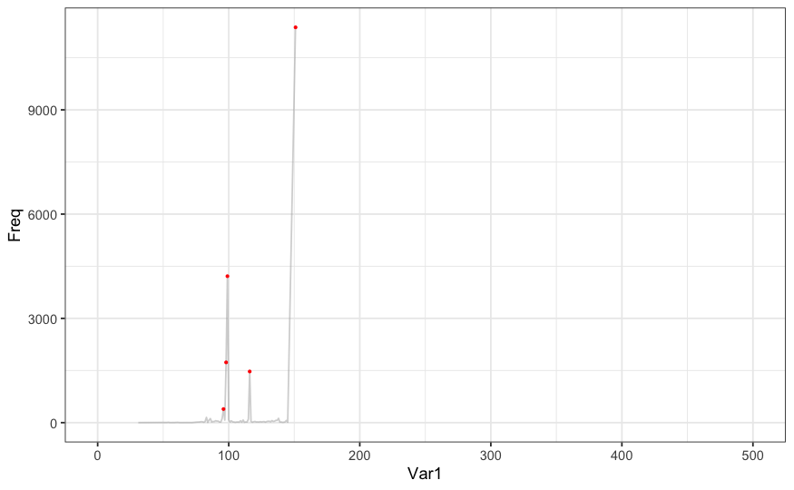

[output not shown]

[output not shown]

[figure not shown]

```r
system(
paste('cutadapt -a ', #replace by your path to cutadapt
      '"', 'GGGGGGGGGG',';required;min_overlap=10','"','...', 'GGGGGGGGGG',
      ' -A ', '"','GGGGGGGGGG',';required;min_overlap=10','"', '...', 'GGGGGGGGGG',
      ' --discard-untrimmed',
      ' --minimum-length=', minlength, #minimum length for sequences after trimming
      ' --cores=', Cores, # Number of cores to use
      #' -o ', paste(path_demulti, '/', forward_raw[1], sep = ''),
      #' -p ', paste(path_demulti, '/', reverse_raw[1], sep = ''),
      paste(' ',path_demulti , '/', forward_raw[1], sep = ''),
      paste(' ', path_demulti, '/', reverse_raw[1], sep = ''),
      ' --report=minimal',
      sep = ''
      ), intern = TRUE
)
```